# MyKmeans

```python
%matplotlib notebook
```

```python
# loading standard modules
import numpy as np
import math
import matplotlib.pyplot as plt
from skimage import img_as_ubyte
from skimage.color import rgb2grey

# loading custom module (requires file asg1.py in the same directory as the notebook file)
from asg1 import Figure, KmeansPresenter
```

```python
class MyKmeansApp:

    def __init__(self, img, num_clusters, weightXY):
        self.k = num_clusters
        print 'K = ',self.k
        self.w = weightXY
        print 'weightXY =',self.w
        self.iteration = 0   # iteration counter
        self.energy = np.infty  # energy - "sum of squared errors" (SSE)

        num_rows = self.num_rows = img.shape[0]
        num_cols = self.num_cols = img.shape[1]

        self.im = img

        self.means = np.zeros((self.k,5),'d') # creates a zero-valued (double) matrix of size Kx5
        self.init_means()
        self.no_label = num_clusters  # special label value indicating pixels not in any cluster (e.g. not yet)
        # mask "labels" where pixels of each "region" will have a unique index-label (like 0,1,2,3,..,K-1)
        # the default mask value is "no-label" (K) implying pixels that do not belong to any region (yet)
        self.labels = np.full((num_rows, num_cols), fill_value=self.no_label, dtype=np.int)
        self.fig = Figure()
        self.pres = KmeansPresenter(img, self)
        self.pres.connect_figure(self.fig)
    def run(self):
        self.fig.show()

    def init_means(self):
        self.iteration = 0           # resets iteration counter
        self.energy = np.infty       # and the energy

        poolX = range(self.num_cols)
        poolY = range(self.num_rows)

        # generate K random pixels (Kx2 array with X,Y coordinates in each row)
        random_pixels = np.array([np.random.choice(poolX,self.k),np.random.choice(poolY,self.k)]).T

        for label in range(self.k):
            self.means[label,:3] = self.im[random_pixels[label,1],random_pixels[label,0],:3]
            self.means[label,3] = random_pixels[label,0]
            self.means[label,4] = random_pixels[label,1]

    # This function compute average values for R, G, B, X, Y channel (feature component) at pixels in each cluster
    # represented by labels in given mask "self.labels" storing indeces in range [0,K). The averages should be
    # saved in (Kx5) matrix "self.means". The return value should be the number of non-empty clusters.
    def compute_means(self):
        labels = self.labels
        non_empty_clusters = 0

        # Your code below should compute average values for R,G,B,X,Y features in each segment
        # and save them in (Kx5) matrix "self.means". For empty clusters set the corresponding mean values
        # to infinity (np.infty). Report the correct number of non-empty clusters by the return value.

        # loop through the number of clusters's means
        for i in range(self.k):
            newmean = np.zeros(5)
        #find pixals where the labels equal to the cluster
            p = np.where(labels == i)
        #convert into (x,y) coordinate
            q = np.transpose(p)
            #access each single point in q
            for j in q:
        #compute the mean for the cluster

                rgb = self.im[j[0],j[1]]
                newmean += np.array([rgb[0],rgb[1],rgb[2],j[0],j[1]])
        #size is the number of pixals in this clusters
            size = q.size
            if size != 0:
                non_empty_clusters+=1
                self.means[i] = newmean/size
            else:
        #set the mean to infinity if there is no pixal in this cluster
                self.means[i] = np.infty

        return non_empty_clusters

    # The segmentation mask is used by KmeanPresenter to paint segments in distinct colors
    # NOTE: valid region labels are in [0,K), but the color map in KmeansPresenter
    #       accepts labels in range [0,K] where pixels with no_label=K are not painted/colored.
    def get_region_mask(self):
        return self.labels

    # This function computes optimal (cluster) index/label in range 0,1,...,K-1 for pixel x,y based on
    # given current cluster means (self.means). The functions should save these labels in "self.labels".
    # The return value should be the corresponding optimal SSE.
    def compute_labels(self):
        shape = (self.num_rows,self.num_cols)
        opt_labels = np.full(shape, fill_value=self.no_label, dtype=np.int) # HINT: you can use this array to store and update
                                                                            # currently the best label for each pixel.

        min_dist = np.full(shape, fill_value=np.inf)  # HINT: you can use this array to store and update
                                                      # the (squared) distance from each pixel to its current "opt_label".
                                                      # use 'self.w' as a relative weight of sq. errors for X and Y components

        # Replace the code below by your code that computes "opt_labels" array of labels in range [0,K) where
        # each pixel's label is an index 'i' such that self.mean[i] is the closest to R,G,B,X,Y values of this pixel.
        # Your code should also update min_dist so that it contains the optmail squared errors

        #looping through the picture, calculate the mean to each cluster centre, if it is smaller,replace the label and
        #updated
        for x in range(self.num_rows):
            for y in range(self.num_cols):
                index = 0
                for i in self.means:
                    pre_dist = min_dist[x,y]
                    rgb = self.im[x,y]
                    cur_dist = (rgb[0]-i[0]) **2 + (rgb[1]-i[1])**2 + (rgb[2]-i[2])**2 + self.w*(x - i[3])**2 + self.w*(y-i[4])**2
                    if cur_dist < pre_dist:
                        opt_labels[x,y] = index
                        min_dist[x,y] = cur_dist
                    else:
                        continue
                    index +=1

        # update the labels based on opt_labels computed above
        self.labels = opt_labels
        # returns the optimal SSE (corresponding to optimal clusters/labels for given means)
        return min_dist.sum()

    # The function below is called by "on_key_down" in KmeansPresenter".
    # It's goal is to run an iteration of K-means procedure
    # updating the means and the (segment) labels
    def compute_k_means_clusters(self):
        self.iteration += 1
        # the main two steps of K-means algorithm
        energy = self.compute_labels()
        num_clusters = self.compute_means()
        # computing improvement and printing some information
        num_pixels = self.num_rows*self.num_cols
        improve_per_pixel = (self.energy - energy)/num_pixels
        energy_per_pixel = energy/num_pixels
        self.energy = energy

        self.fig.ax.text(0, -8,   # text location
                         'iteration = {:_>2d},  clusters = {:_>2d},  SSE/p = {:_>7.1f},   improve/p = {:_>7.3f}    '.format(
                          self.iteration,       num_clusters,        energy_per_pixel,    improve_per_pixel),
                          bbox={'facecolor':'white', 'edgecolor':'none'})

        return improve_per_pixel
```

### Notes about K-means implementation:

1. press 'i'-key for each (i)teration of K-means
2. press 'c'-key to run K-means to (c)onvergence (when energy improvement is less than given threshold)
3. press 'v'-key to run K-means to convergence with (v)isualization of each iteration
4. press 'r'-key to start over from (r)andom means
5. press 's'-key to change to a random (s)olid color-palette for displaying clusters
6. press 't'-key to change to a random (t)ransparent palette for displaying clusters
7. press 'm'-key to change to the (m)ean-color palette for displaying clusters

# Different value of weightXY for the same numebr of Clusters

# Choose K = 10

1. weightXY = 3.0
1. weightXY = 1.0
1. weightXY = 7.0

```
K =  10
weightXY = 3.0
```

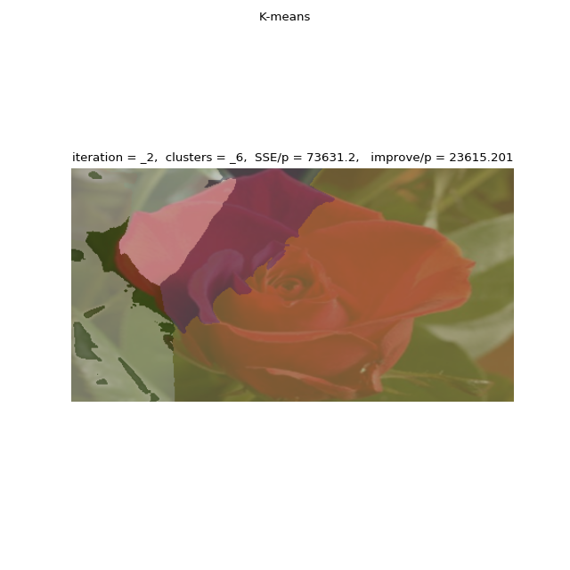

```python
img = plt.imread('images/rose.bmp')
app = MyKmeansApp(img, 10, weightXY=3.0)
app.run()
```

```
K =  10
weightXY = 1.0
```

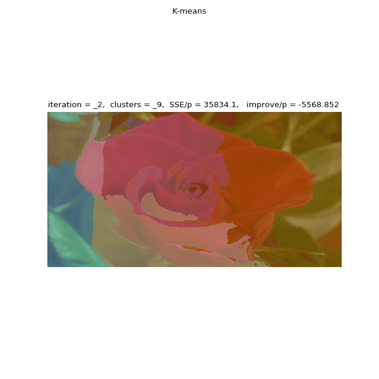

```python
img = plt.imread('images/rose.bmp')
app = MyKmeansApp(img, 10, weightXY=1.0)
app.run()
```

```
K =  10
weightXY = 7.0
```

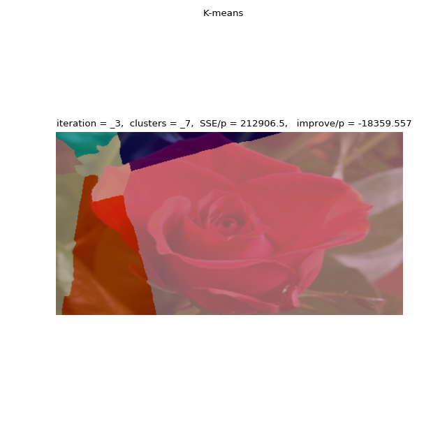

```python
img = plt.imread('images/rose.bmp')
app = MyKmeansApp(img, 10, weightXY=7.0)
app.run()
```

# Discussion for the different values of weightXY

For lower values of weightXY, the segmentation appear to be more as the area where the colour differs more, because in the calculation of SSE, the value where the weightXY get multiply influence less, so the segmentation will be close to the clusters where RGB values are more close, which is shown in the difference between the first output and the second output, we can see that the second output marks the boundary of the colour difference more clear than the first one.

While for the higher values of weightXY, the segmentation, the segmentation get influenced more by the where the pixels is closer to the mean of k, which is a random mean chosen values. Therefore, it will appear close to the wherever the initial means location. As it is shown in the output of the third output and the first output, the segmentation seems not accurate because in the weight function, the value of X,Y influenced the results much more than the RBG values.

For their properties,for 2D image that has rich colours, it may be a good idea to choose less weight for x,y in the formula.However,for picture that requires some coordinate information for segmentation, it may be good to choose higher weight of X,Y. For example, maybe 3D picture.